# Run models for FishMIP

Author

Max Lindmark

Published

2024-03-14

## Model runs

Testing the mizer model with FishMIP (temperature, fishing and plankton).

## Set up the environment

We are using a local mizer version (mizer-rewiring), described [here](https://onlinelibrary.wiley.com/doi/abs/10.1111/gcb.16341), with additional adaptations made to accomodate FishMIP forcings. The workflow to download and prepare are described in html and qmd files in the folders FishingForcing, Temperature, and plankton. The raw data files are too big for github, but there are instructions on how to download them. In those files I also explore forcings and describe assumptions I made. In short:

- Fishing effort: Scaled to max across years, by fish species. Then I fit a regression to get a correction factor (by species) to increase this max-scaled FishMIP effort to match the assessment. I find this is the best approach (also tried mean-scaling and multiplying with the assessment effort), but this leads to very spiky efforts with some values being too high
- Temperature: I aggregate by year, since my model is not seasonally resolved
- Plankton: I follow the Hawaii model and assign sizes to the plankton groups. I next fit a regression (log-log of abundance and weight interacting with date [year-month]) to get the size-spectrum slopes for each month and year. Since they are very different from the default mizer model slopes and intercepts, I divide each time steps slope and intercept by the mean across the whole time series. Lastly I remove seasonality by averaging across years.

```r
library(tidyverse); theme_set(theme_light())
library(RColorBrewer)
library(RCurl)
library(tidylog)
library(mizer) # local build! if not installed, install in "Build" tab

home <- here::here()
```

## Read data and parameters

We’ll read the default parameters from the Baltic mizer to test we can reproduce the old results with the modified project function and the additional arguments `plankton_forcing = TRUE`, and `plankton_forcing_array = plankton_forcing_array_dt`.

```r
# Read in
balticParams <- read.csv(text = getURL("https://raw.githubusercontent.com/maxlindmark/mizer-rewiring/rewire-temp/baltic/params/species_params.csv"), sep = ";")

# Read in params object
params <- readRDS(paste0(home, "/baltic/params/mizer_param_calib.rds"))

# Read in old effort
projectEffort_old <- read_csv(paste0(home, "/baltic/params/projectEffort.csv"))[, 2:4]

# Read in temperature. This started from 1874 ...
projectTemp_old <- read_csv(paste0(home, "/baltic/params/projectTemp.csv"))[, 2:3]

# New temperature. This is a 600 length df with monthly temperatures between 1961 and 2010
projectTemp <- read_csv(paste0(home, "/baltic/FishMIP/Input-mizer/temp_df.csv")) %>%
  mutate(year = year(date))

projectEffort_old <- projectEffort_old %>%
  mutate(year = projectTemp_old$Year) %>%
  filter(year %in% c(projectTemp$year))

# Now I need to expand each row 12 times. Easy is to just left join into the correct dimensions
projectEffort_old <- projectTemp %>%
  left_join(projectEffort_old, by = "year") %>%
  dplyr::select(-temp_agg, -temp, -date, -year)

# OK looks good. Now make this a matrix
projectEffort_old_m <- as.matrix(projectEffort_old)
rownames(projectEffort_old_m) <- 1:nrow(projectEffort_old_m)

# This the the effort matrix used in the calibration
projectEffort_const <- as.matrix(projectEffort_old %>% mutate(Cod = 0.899, Herring = 0.306, Sprat = 0.340))
rownames(projectEffort_const) <- 1:nrow(projectEffort_const)

# Read in FishMIP effort
projectEffort <- read_csv(paste0(home, "/baltic/FishMIP/Input-mizer/projectEffort_df.csv")) %>%
  filter(source2 == "FishMIP F scaled") %>%
  dplyr::select("year", "sp", "effort") %>%
  pivot_wider(names_from = sp, values_from = effort)

# Now I need to expand each row 12 times. Easy is to just left join into the correct dimensions
projectEffort <- projectTemp %>%
  left_join(projectEffort, by = "year") %>%
  dplyr::select(-temp_agg, -temp, -date, -year)

# OK looks good. Now make this a matrix
projectEffort <- as.matrix(projectEffort)
rownames(projectEffort) <- 1:nrow(projectEffort)
```

## Check the GCB paper baseline in this new, modified FishMIP-mizer

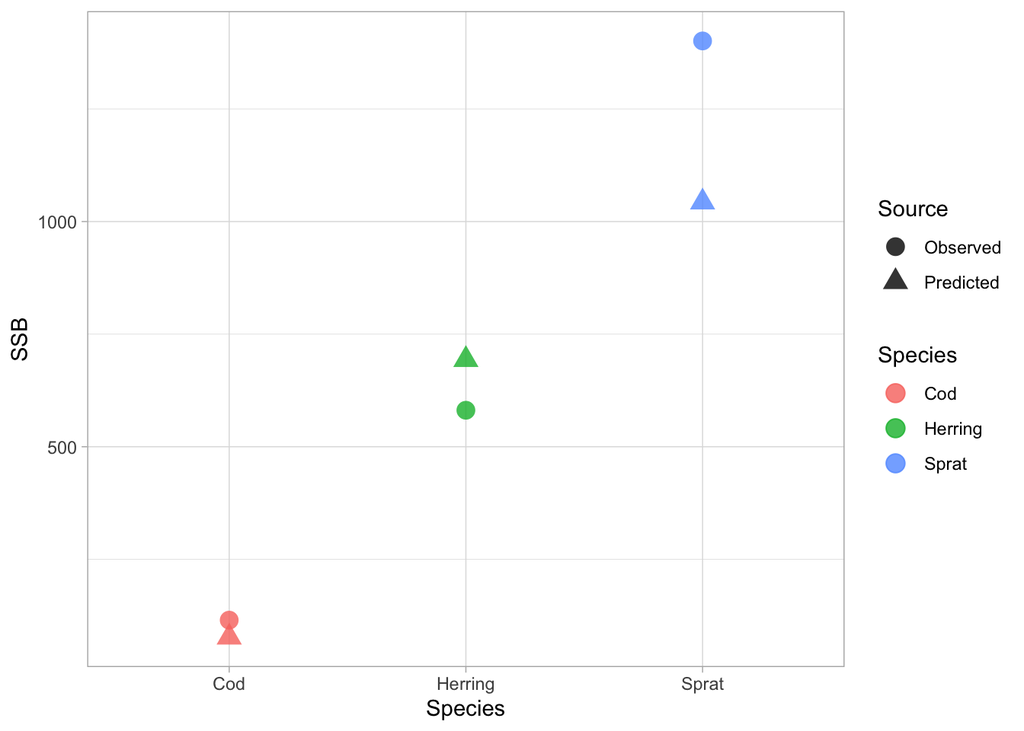

```r
# First see if I can reproduce the fit to data "SSB_fit.png"
gcb <- project(params,
               dt = 0.2,
               effort = projectEffort_const,
               temperature = rep(10.11562, 600), # This is the t_ref
               t_max = 600,
               plankton_forcing = FALSE
               )

obs <- balticParams$AveSpawnBiomass
pred <- colMeans(getSSB(gcb)[c(I(dim(gcb@n)[1]-20):dim(gcb@n)[1]), ] ) * 2.49e+11 / (1e9)

ssb_eval <- data.frame(SSB = c(obs, pred),
                       Source = rep(c("Observed", "Predicted"), each = 3),
                       Species = rep(balticParams$species, 2))

ggplot(ssb_eval, aes(Species, SSB, shape = Source, color = Species)) +
  geom_point(size = 4, alpha = 0.8)
```

```r
# Yes!
```

Ok, good! The approach for FishMIP is as follows:

```r
# Calibration time period in the FishMIP model is 1992-2004
effort_means <- read_csv(paste0(home, "/baltic/FishMIP/Input-mizer/projectEffort_df.csv")) %>%
  filter(source2 == "FishMIP F scaled",
         year >= 1992 & year <= 2004) %>%
  summarise(mean_effort = mean(effort), .by = "sp")

# The effort in the FishMIP runs are slightly higher. That's why we see a slightly lower SSB in the simulations in the baseline scenarios
projectEffort_const[1, ]
```

```
    Cod Herring   Sprat
  0.899   0.306   0.340
```

```r
effort_means
```

```
# A tibble: 3 × 2
  sp      mean_effort
  <chr>         <dbl>
1 Cod           0.839
2 Sprat         0.528
3 Herring       0.463
```

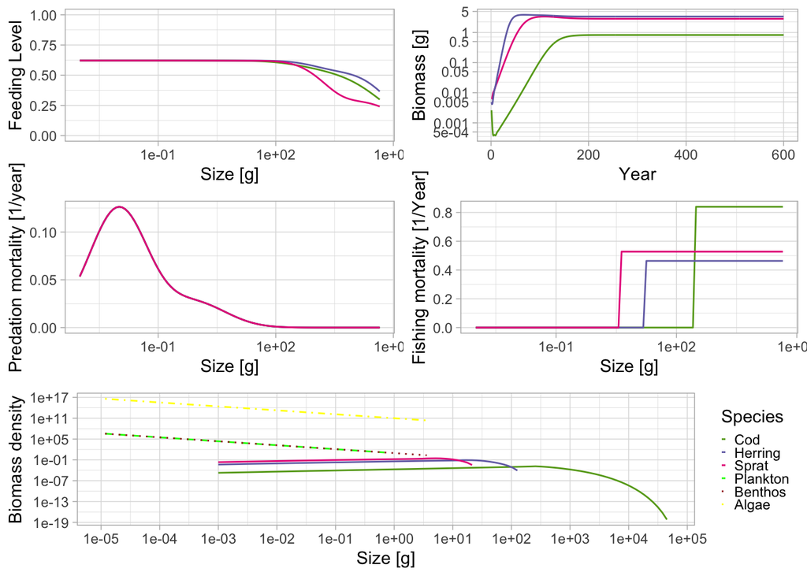

```r
projectEffort_cali <- projectEffort
projectEffort_cali[, 1] <- as.numeric(effort_means[effort_means$sp == "Cod", "mean_effort"])
projectEffort_cali[, 2] <- as.numeric(effort_means[effort_means$sp == "Sprat", "mean_effort"])
projectEffort_cali[, 3] <- as.numeric(effort_means[effort_means$sp == "Herring", "mean_effort"])

temperature_cali <- projectTemp %>%
  filter(year >= 1992 & year <= 2004) %>%
  summarise(mean_temp = mean(temp)) %>%
  pull(mean_temp)

# projectTemp %>%
#   filter(year >= 1992 & year <= 2004) %>%
#   ggplot(aes(date, temp)) +
#   geom_line()

# Update params object with new t_ref
# t <- params@species_params
#
# params_fishmip <- MizerParams(t,
#                               t_ref = temperature_cali)

ref <- project(params,
               dt = 0.2,
               effort = projectEffort_cali,
               temperature = rep(temperature_cali, 600),
               t_max = 600,
               plankton_forcing = FALSE
               )

plot(ref)
```

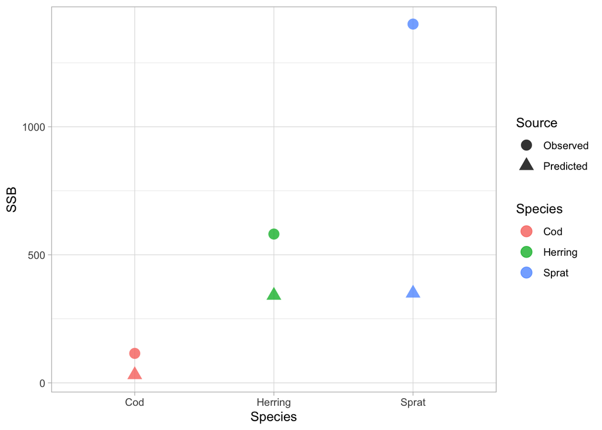

```r
# This is the fit when I use average temperatures and fishing efforts from mizer, but maintain t_ref
obs <- balticParams$AveSpawnBiomass
pred <- colMeans(getSSB(ref)[c(I(dim(ref@n)[1]-20):dim(ref@n)[1]), ] ) * 2.49e+11 / (1e9)

ssb_eval <- data.frame(SSB = c(obs, pred),
                       Source = rep(c("Observed", "Predicted"), each = 3),
                       Species = rep(balticParams$species, 2))

ggplot(ssb_eval, aes(Species, SSB, shape = Source, color = Species)) +
  geom_point(size = 4, alpha = 0.8)
```

This looks ok! We are not expecting the last plot to fit nicely with FishMIP fishing efforts because the model was not calibrated to match those observed SSBs with the FishMIP efforts. We mainly want to see that it works (feeding levels OK and biomasses in the ballpark)

Now I want to use plankton forcing, by setting `plankton_forcing = TRUE`. I then need to provide a plankton array that is dt-spaced. I extract a template from the semi-chemostat steady-state plankton spectrum from the ref model

First just do the steady state values without any FishMIP relative modifications

```r
plankton_forcing_array <- ref@n_pp

# Now expand by dt
# test <- plankton_forcing_array[1:3, 1:4]
# test[2, ] <- test[1, ]*0.5
# test[3, ] <- test[1, ]*1.5
#
# test2 <- array(data = NA,
#                dim = c(nrow(test) * 1/dt,
#                        ncol(test)))
#
# test2[] <- rep(test, each = 1/dt)
# test2
dt <- 0.2 # for the project function, this needs to be dt-spaced
plankton_forcing_array_dt <- array(data = NA,
                                   dim = c(nrow(plankton_forcing_array) * (1/dt),
                                           ncol(plankton_forcing_array)),
                                   dimnames = list(time = c(1:3000),
                                                   w = colnames(plankton_forcing_array)))

str(plankton_forcing_array_dt)
```

```
 logi [1:3000, 1:164] NA NA NA NA NA NA ...
 - attr(*, "dimnames")=List of 2
  ..$ time: chr [1:3000] "1" "2" "3" "4" ...
  ..$ w   : chr [1:164] "1.13e-08" "1.35e-08" "1.61e-08" "1.93e-08" ...
```

```r
colnames(plankton_forcing_array_dt)
```

```
  [1] "1.13e-08" "1.35e-08" "1.61e-08" "1.93e-08" "2.3e-08"  "2.75e-08"
  [7] "3.29e-08" "3.93e-08" "4.69e-08" "5.61e-08" "6.7e-08"  "8e-08"
 [13] "9.56e-08" "1.14e-07" "1.37e-07" "1.63e-07" "1.95e-07" "2.33e-07"
 [19] "2.78e-07" "3.32e-07" "3.97e-07" "4.75e-07" "5.67e-07" "6.77e-07"
 [25] "8.09e-07" "9.67e-07" "1.16e-06" "1.38e-06" "1.65e-06" "1.97e-06"
 [31] "2.35e-06" "2.81e-06" "3.36e-06" "4.02e-06" "4.8e-06"  "5.73e-06"
 [37] "6.85e-06" "8.18e-06" "9.78e-06" "1.17e-05" "1.4e-05"  "1.67e-05"
 [43] "1.99e-05" "2.38e-05" "2.85e-05" "3.4e-05"  "4.06e-05" "4.85e-05"
 [49] "5.8e-05"  "6.93e-05" "8.28e-05" "9.89e-05" "0.000118" "0.000141"
 [55] "0.000169" "0.000202" "0.000241" "0.000288" "0.000344" "0.000411"
 [61] "0.000491" "0.000586" "0.000701" "0.000837" "0.001"    "0.00119"
 [67] "0.00143"  "0.00171"  "0.00204"  "0.00243"  "0.00291"  "0.00348"
 [73] "0.00415"  "0.00496"  "0.00593"  "0.00708"  "0.00846"  "0.0101"
 [79] "0.0121"   "0.0144"   "0.0172"   "0.0206"   "0.0246"   "0.0294"
 [85] "0.0351"   "0.042"    "0.0502"   "0.06"     "0.0716"   "0.0856"
 [91] "0.102"    "0.122"    "0.146"    "0.174"    "0.208"    "0.249"
 [97] "0.297"    "0.355"    "0.425"    "0.507"    "0.606"    "0.724"
[103] "0.865"    "1.03"     "1.24"     "1.48"     "1.76"     "2.11"
[109] "2.52"     "3.01"     "3.59"     "4.29"     "5.13"     "6.13"
[115] "7.32"     "8.75"     "10.5"     "12.5"     "14.9"     "17.8"
[121] "21.3"     "25.5"     "30.4"     "36.3"     "43.4"     "51.9"
[127] "62"       "74.1"     "88.5"     "106"      "126"      "151"
[133] "180"      "215"      "257"      "308"      "368"      "439"
[139] "525"      "627"      "749"      "895"      "1070"     "1280"
[145] "1530"     "1820"     "2180"     "2600"     "3110"     "3720"
[151] "4440"     "5310"     "6340"     "7570"     "9050"     "10800"
[157] "12900"    "15400"    "18400"    "22000"    "26300"    "31500"
[163] "37600"    "44900"
```

```r
# Get the steady_state planktong resource array
steady_state <- plankton_forcing_array[600, ]

# They look extremely similar but are in fact not identical
# The initial approximation must be really good...
# plot(ref@n_pp[600, ])
# lines(ref@n_pp[600, ], col="red")
# lines(ref@n_pp[1, ], col="blue")
# lines(ref@params@initial_n_pp, col="green")
# identical(ref@params@initial_n_pp, ref@n_pp[1, ])
# identical(ref@params@initial_n_pp, ref@n_pp[600, ])

# Loop in the steady state plankton densities by size for each time step

for(i in 1:nrow(plankton_forcing_array_dt)) {

  plankton_forcing_array_dt[i, ] <- steady_state

}

str(plankton_forcing_array_dt)
```

```
 num [1:3000, 1:164] 8.09e+17 8.09e+17 8.09e+17 8.09e+17 8.09e+17 ...
 - attr(*, "dimnames")=List of 2
  ..$ time: chr [1:3000] "1" "2" "3" "4" ...
  ..$ w   : chr [1:164] "1.13e-08" "1.35e-08" "1.61e-08" "1.93e-08" ...
```

```r
# This code shows that the array is now populated with the steady state plankton abundance from the semi-chemostat for all time steps
# plot(plankton_forcing_array_dt[, 10]); abline(a = steady_state[10], col = "red", b = 0)
# plot(ref@n_pp[, 10]); abline(a = steady_state[10], col = "red", b = 0)
# plot(ref@n_pp[600, ])#; abline(a = steady_state[10], col = "red", b = 0)
# lines(plankton_forcing_array_dt[1, ], col = "red")
# lines(plankton_forcing_array_dt[600, ], col = "blue", lty = 2)
```

Now run the model with plankton forcing, but use the steady state plankton at all time steps

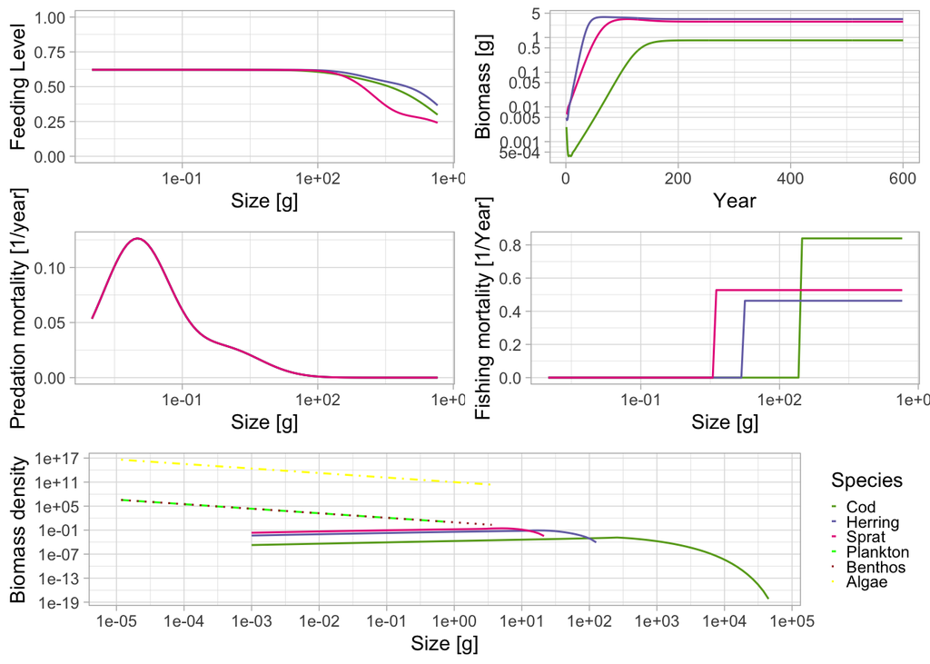

```r
test <- project(params,
                dt = 0.2,
                effort = projectEffort_cali,
                temperature = rep(temperature_cali, 600),
                t_max = 600,
                plankton_forcing = TRUE,
                plankton_forcing_array = plankton_forcing_array_dt
                )

plot(test)
```

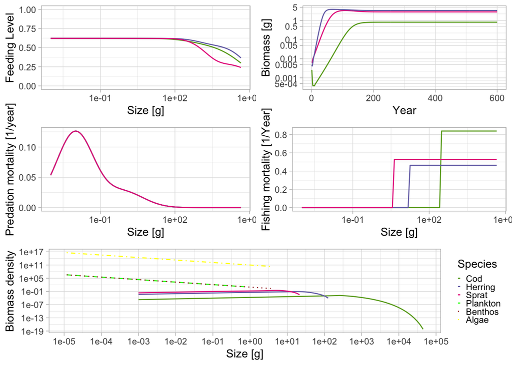

```r
plot(ref)
```

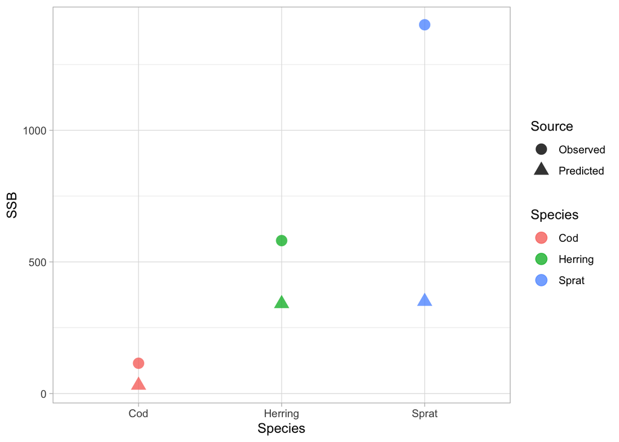

```r
# The reason they look so similar is because there so small changes in the plankton densities at steady state compared to the inital n!!
obs <- balticParams$AveSpawnBiomass
pred <- colMeans(getSSB(test)[c(I(dim(test@n)[1]-20):dim(test@n)[1]), ] ) * 2.49e+11 / (1e9)

ssb_eval <- data.frame(SSB = c(obs, pred),
                       Source = rep(c("Observed", "Predicted"), each = 3),
                       Species = rep(balticParams$species, 2))

ggplot(ssb_eval, aes(Species, SSB, shape = Source, color = Species)) +
  geom_point(size = 4, alpha = 0.8)
```

The model at steady state with plankton forcing but values kept at steady state is the same as the the one without forcing (yay?!)

```r
colMeans(getSSB(test)[c(I(dim(test@n)[1]-20):dim(test@n)[1]), ] ) * 2.49e+11 / (1e9)
```

```
      Cod     Sprat   Herring
 31.21124 349.70471 341.24374
```

```r
colMeans(getSSB(ref)[c(I(dim(ref@n)[1]-20):dim(ref@n)[1]), ] ) * 2.49e+11 / (1e9)
```

```
      Cod     Sprat   Herring
 31.21124 349.70471 341.24374
```

Next I need to get the intercept and slope of the plankton spectrum so that I can reproduce the steady_state with an equation

Before I do that, I need the biomass spectra, i.e., get the sizes in each class and multiply with abundance

```r
fit_df <- tibble(n = as.numeric(steady_state),
                 mass = as.numeric(colnames(test@n_pp))) %>%
  filter(n > 0) %>%
  mutate(log10_n = log10(n),
         log10_mass = log10(mass))

max(fit_df$mass)
```

```
[1] 0.865
```

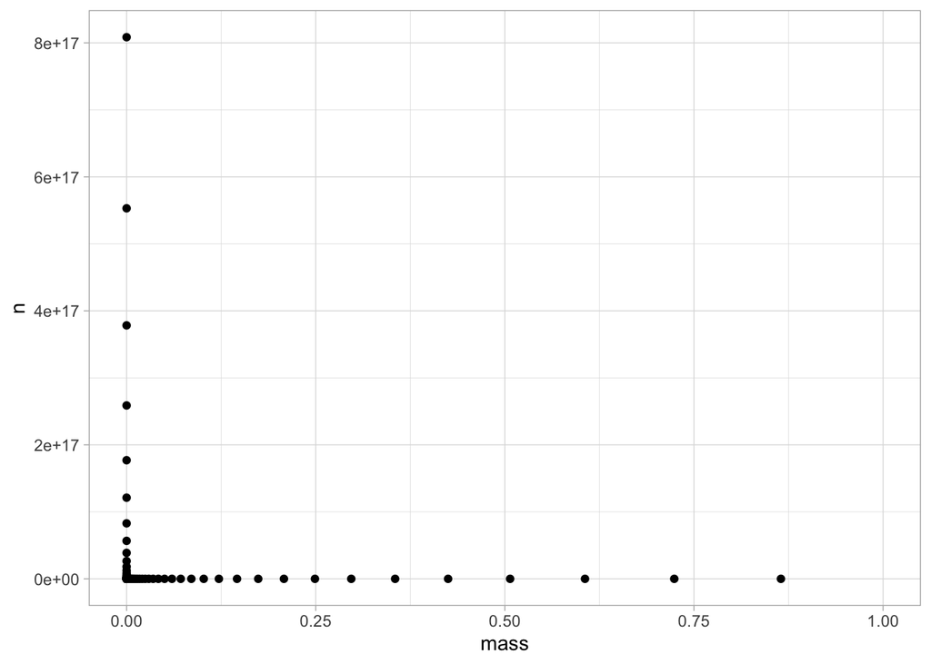

```r
# Well, it's above cutoff for sure
ggplot(fit_df, aes(mass, n)) +
  geom_point() +
  coord_cartesian(xlim = c(0, 1))
```

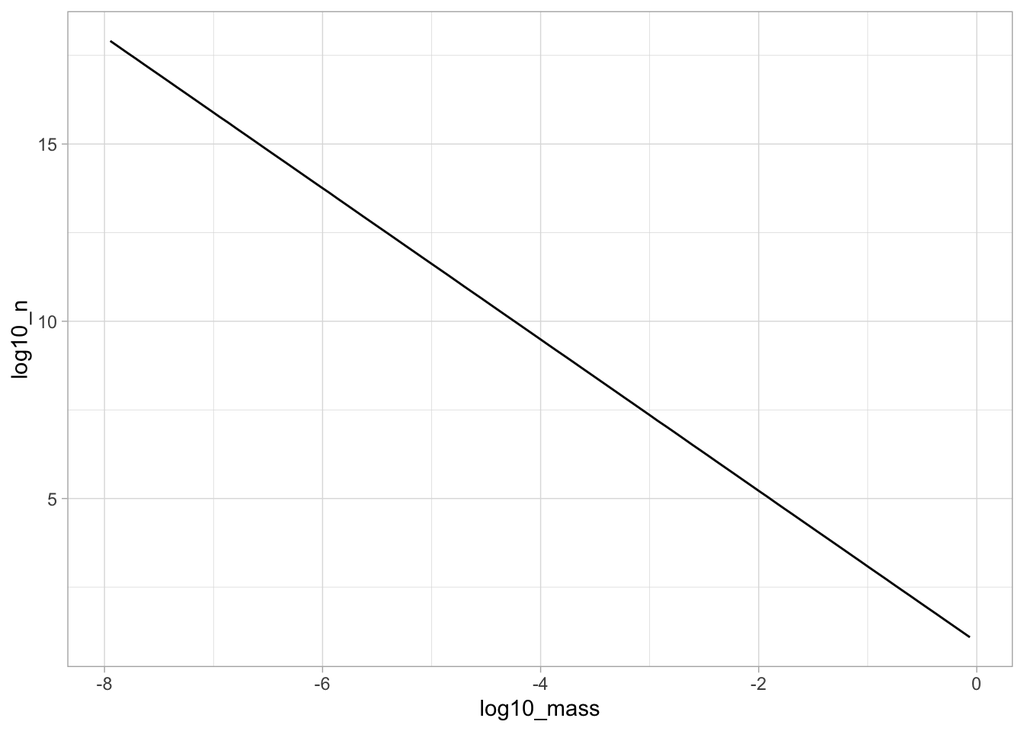

```r
ggplot(fit_df, aes(log10_mass, log10_n)) +
  geom_line()
```

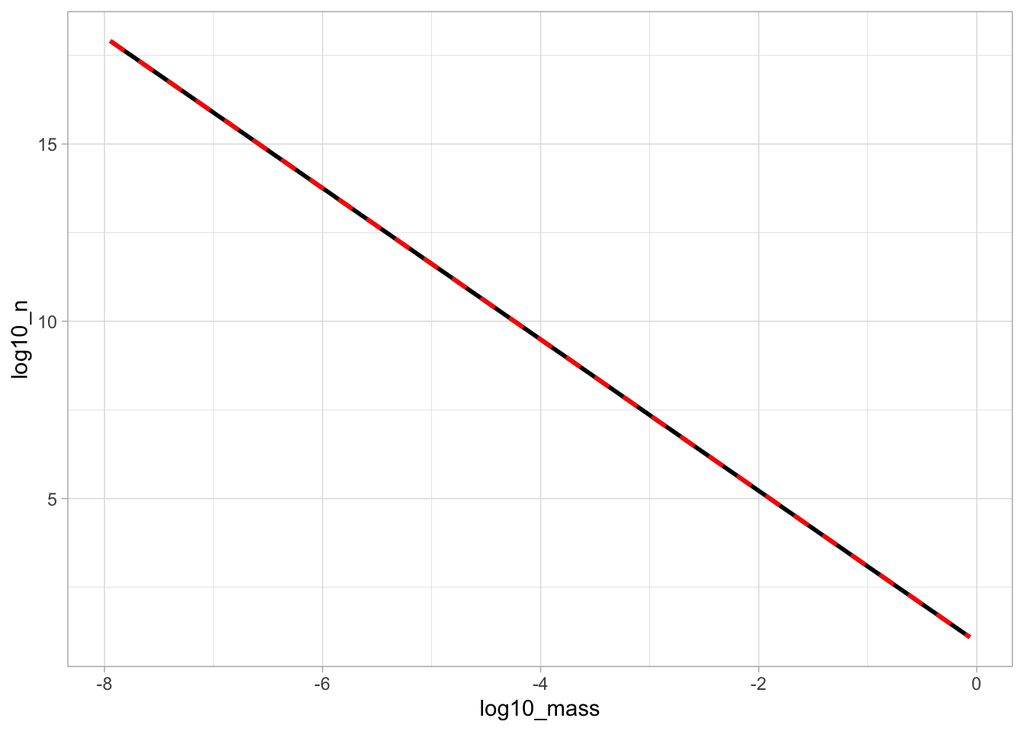

```r
# Estimate the intercept and the slope in the steady state plankton from the semi-chemostat
m <- lm(log10_n ~ log10_mass, data = fit_df) %>% broom::tidy()
steady_intercept <- m %>% filter(term == "(Intercept)") %>% pull(estimate)
steady_slope <- m %>% filter(term == "log10_mass") %>% pull(estimate)

# Ok, looks good! Can I reproduce the steady state vector?
res <- tibble(n = as.numeric(steady_state),
              mass = as.numeric(colnames(test@n_pp))) %>%
  filter(n > 0) %>%
  mutate(log10_n = log10(n),
         log10_mass = log10(mass)) %>%
  mutate(pred_log10_n = steady_intercept + steady_slope*log10_mass,
         pred_n = 10^pred_log10_n)

ggplot(res) +
  geom_line(aes(log10_mass, log10_n), linewidth = 1) +
  geom_line(aes(log10_mass, pred_log10_n), linetype = 2, color = "red", linewidth = 1)
```

```r
# Ok, now make a data frame with 600 intercepts and slopes, then read in the relative FishMIP scaling and scale the intercept and slopes that I use to populate the array
plankton_scalars <- read_csv(paste0(home, "/baltic/FishMIP/Input-mizer/resource_df.csv")) %>%
  rename(rel_intercept = intercept,
         rel_slope = slope) %>%
  # add in the steady-state slope and intercept
  mutate(steady_intercept = steady_intercept,
         steady_slope = steady_slope) %>%
  # add the perturbation
  mutate(fishmip_intercept = steady_intercept * rel_intercept,
         fishmip_slope = steady_slope * rel_slope)

plankton_scalars
```

```
# A tibble: 600 × 7
   date       rel_intercept rel_slope steady_intercept steady_slope
   <date>             <dbl>     <dbl>            <dbl>        <dbl>
 1 1961-01-01          1.09     0.991            0.952        -2.13
 2 1961-02-01          1.09     0.991            0.952        -2.13
 3 1961-03-01          1.09     0.991            0.952        -2.13
 4 1961-04-01          1.09     0.991            0.952        -2.13
 5 1961-05-01          1.09     0.991            0.952        -2.13
 6 1961-06-01          1.09     0.991            0.952        -2.13
 7 1961-07-01          1.09     0.991            0.952        -2.13
 8 1961-08-01          1.09     0.991            0.952        -2.13
 9 1961-09-01          1.09     0.991            0.952        -2.13
10 1961-10-01          1.09     0.991            0.952        -2.13
# ℹ 590 more rows
# ℹ 2 more variables: fishmip_intercept <dbl>, fishmip_slope <dbl>
```

```r
# Now create 600 perturbed "steady state" vectors
# Test first again I can reproduce the steady (taking the first value of the 600 rows)
# steady_state_sc_test <- 10^ (plankton_scalars$steady_intercept[1] +
#   plankton_scalars$steady_slope[1] * log10(as.numeric(names(steady_state_sc))))

str(plankton_forcing_array)
```

```
 num [1:600, 1:164] 8.09e+17 8.09e+17 8.09e+17 8.09e+17 8.09e+17 ...
 - attr(*, "dimnames")=List of 2
  ..$ time: chr [1:600] "1" "2" "3" "4" ...
  ..$ w   : chr [1:164] "1.13e-08" "1.35e-08" "1.61e-08" "1.93e-08" ...
```

```r
colnames(plankton_forcing_array)
```

```
  [1] "1.13e-08" "1.35e-08" "1.61e-08" "1.93e-08" "2.3e-08"  "2.75e-08"
  [7] "3.29e-08" "3.93e-08" "4.69e-08" "5.61e-08" "6.7e-08"  "8e-08"
 [13] "9.56e-08" "1.14e-07" "1.37e-07" "1.63e-07" "1.95e-07" "2.33e-07"
 [19] "2.78e-07" "3.32e-07" "3.97e-07" "4.75e-07" "5.67e-07" "6.77e-07"
 [25] "8.09e-07" "9.67e-07" "1.16e-06" "1.38e-06" "1.65e-06" "1.97e-06"
 [31] "2.35e-06" "2.81e-06" "3.36e-06" "4.02e-06" "4.8e-06"  "5.73e-06"
 [37] "6.85e-06" "8.18e-06" "9.78e-06" "1.17e-05" "1.4e-05"  "1.67e-05"
 [43] "1.99e-05" "2.38e-05" "2.85e-05" "3.4e-05"  "4.06e-05" "4.85e-05"
 [49] "5.8e-05"  "6.93e-05" "8.28e-05" "9.89e-05" "0.000118" "0.000141"
 [55] "0.000169" "0.000202" "0.000241" "0.000288" "0.000344" "0.000411"
 [61] "0.000491" "0.000586" "0.000701" "0.000837" "0.001"    "0.00119"
 [67] "0.00143"  "0.00171"  "0.00204"  "0.00243"  "0.00291"  "0.00348"
 [73] "0.00415"  "0.00496"  "0.00593"  "0.00708"  "0.00846"  "0.0101"
 [79] "0.0121"   "0.0144"   "0.0172"   "0.0206"   "0.0246"   "0.0294"
 [85] "0.0351"   "0.042"    "0.0502"   "0.06"     "0.0716"   "0.0856"
 [91] "0.102"    "0.122"    "0.146"    "0.174"    "0.208"    "0.249"
 [97] "0.297"    "0.355"    "0.425"    "0.507"    "0.606"    "0.724"
[103] "0.865"    "1.03"     "1.24"     "1.48"     "1.76"     "2.11"
[109] "2.52"     "3.01"     "3.59"     "4.29"     "5.13"     "6.13"
[115] "7.32"     "8.75"     "10.5"     "12.5"     "14.9"     "17.8"
[121] "21.3"     "25.5"     "30.4"     "36.3"     "43.4"     "51.9"
[127] "62"       "74.1"     "88.5"     "106"      "126"      "151"
[133] "180"      "215"      "257"      "308"      "368"      "439"
[139] "525"      "627"      "749"      "895"      "1070"     "1280"
[145] "1530"     "1820"     "2180"     "2600"     "3110"     "3720"
[151] "4440"     "5310"     "6340"     "7570"     "9050"     "10800"
[157] "12900"    "15400"    "18400"    "22000"    "26300"    "31500"
[163] "37600"    "44900"
```

```r
rownames(plankton_forcing_array)
```

```
  [1] "1"   "2"   "3"   "4"   "5"   "6"   "7"   "8"   "9"   "10"  "11"  "12"
 [13] "13"  "14"  "15"  "16"  "17"  "18"  "19"  "20"  "21"  "22"  "23"  "24"
 [25] "25"  "26"  "27"  "28"  "29"  "30"  "31"  "32"  "33"  "34"  "35"  "36"
 [37] "37"  "38"  "39"  "40"  "41"  "42"  "43"  "44"  "45"  "46"  "47"  "48"
 [49] "49"  "50"  "51"  "52"  "53"  "54"  "55"  "56"  "57"  "58"  "59"  "60"
 [61] "61"  "62"  "63"  "64"  "65"  "66"  "67"  "68"  "69"  "70"  "71"  "72"
 [73] "73"  "74"  "75"  "76"  "77"  "78"  "79"  "80"  "81"  "82"  "83"  "84"
 [85] "85"  "86"  "87"  "88"  "89"  "90"  "91"  "92"  "93"  "94"  "95"  "96"
 [97] "97"  "98"  "99"  "100" "101" "102" "103" "104" "105" "106" "107" "108"
[109] "109" "110" "111" "112" "113" "114" "115" "116" "117" "118" "119" "120"
[121] "121" "122" "123" "124" "125" "126" "127" "128" "129" "130" "131" "132"
[133] "133" "134" "135" "136" "137" "138" "139" "140" "141" "142" "143" "144"
[145] "145" "146" "147" "148" "149" "150" "151" "152" "153" "154" "155" "156"
[157] "157" "158" "159" "160" "161" "162" "163" "164" "165" "166" "167" "168"
[169] "169" "170" "171" "172" "173" "174" "175" "176" "177" "178" "179" "180"
```

[output cut: 35 more lines]

```r
plankton_forcing_array[] <- 0

str(plankton_forcing_array)
```

```
 num [1:600, 1:164] 0 0 0 0 0 0 0 0 0 0 ...
 - attr(*, "dimnames")=List of 2
  ..$ time: chr [1:600] "1" "2" "3" "4" ...
  ..$ w   : chr [1:164] "1.13e-08" "1.35e-08" "1.61e-08" "1.93e-08" ...
```

```r
# Loop through each of the 600 time steps and perturbate the intercept and slope before calculating the resource array
for(i in 1:nrow(plankton_scalars)) {

  scalars_tmp <- plankton_scalars[i, ]

  steady_state_tmp <-
    10^(scalars_tmp$fishmip_intercept + scalars_tmp$fishmip_slope * log10(as.numeric(names(steady_state))))

  # plot(steady_state_tmp, steady_state); abline(a = 0, b = 1)

  plankton_forcing_array[i, ] <- steady_state_tmp

}

str(plankton_forcing_array)
```

```
 num [1:600, 1:164] 6.87e+17 6.87e+17 6.87e+17 6.87e+17 6.87e+17 ...
 - attr(*, "dimnames")=List of 2
  ..$ time: chr [1:600] "1" "2" "3" "4" ...
  ..$ w   : chr [1:164] "1.13e-08" "1.35e-08" "1.61e-08" "1.93e-08" ...
```

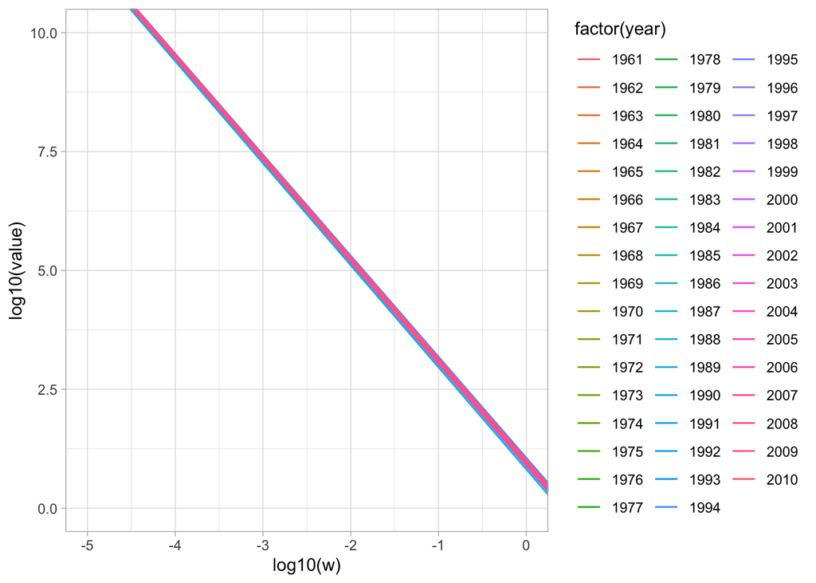

```r
options(max.print = 10000)
# Figure out how to match time...
# t <- reshape2::melt(plankton_forcing_array)
# t %>% head(601)
# str(t)
# Ok so it's 600 time for each body mass, then next body mass and new 600 times
# So I want to repeat 1961, 1961, 1961 ... 12 times for each year until 2010.
# That is length 600. Then it restarts for the next body size (2/164)

# Plot each years resource array
reshape2::melt(plankton_forcing_array) %>%
  mutate(year = rep(rep(1961:2010, each = 12), 164)) %>%
  ggplot(aes(log10(w), log10(value), color = factor(year))) +
  coord_cartesian(xlim = c(-5, 0), ylim = c(0, 10)) +
  geom_line()
```

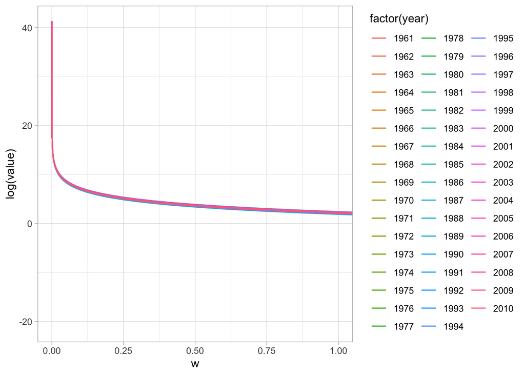

```r
reshape2::melt(plankton_forcing_array) %>%
  mutate(year = rep(rep(1961:2010, each = 12), 164)) %>%
  ggplot(aes(w, log(value), color = factor(year))) +
  coord_cartesian(xlim = c(0, 1)) +
  geom_line()
```

```r
# Now loop again and make it dt-spaced
plankton_forcing_array_dt[] <- 0
colnames(plankton_forcing_array_dt)
```

```
  [1] "1.13e-08" "1.35e-08" "1.61e-08" "1.93e-08" "2.3e-08"  "2.75e-08"
  [7] "3.29e-08" "3.93e-08" "4.69e-08" "5.61e-08" "6.7e-08"  "8e-08"
 [13] "9.56e-08" "1.14e-07" "1.37e-07" "1.63e-07" "1.95e-07" "2.33e-07"
 [19] "2.78e-07" "3.32e-07" "3.97e-07" "4.75e-07" "5.67e-07" "6.77e-07"
 [25] "8.09e-07" "9.67e-07" "1.16e-06" "1.38e-06" "1.65e-06" "1.97e-06"
 [31] "2.35e-06" "2.81e-06" "3.36e-06" "4.02e-06" "4.8e-06"  "5.73e-06"
 [37] "6.85e-06" "8.18e-06" "9.78e-06" "1.17e-05" "1.4e-05"  "1.67e-05"
 [43] "1.99e-05" "2.38e-05" "2.85e-05" "3.4e-05"  "4.06e-05" "4.85e-05"
 [49] "5.8e-05"  "6.93e-05" "8.28e-05" "9.89e-05" "0.000118" "0.000141"
 [55] "0.000169" "0.000202" "0.000241" "0.000288" "0.000344" "0.000411"
 [61] "0.000491" "0.000586" "0.000701" "0.000837" "0.001"    "0.00119"
 [67] "0.00143"  "0.00171"  "0.00204"  "0.00243"  "0.00291"  "0.00348"
 [73] "0.00415"  "0.00496"  "0.00593"  "0.00708"  "0.00846"  "0.0101"
 [79] "0.0121"   "0.0144"   "0.0172"   "0.0206"   "0.0246"   "0.0294"
 [85] "0.0351"   "0.042"    "0.0502"   "0.06"     "0.0716"   "0.0856"
 [91] "0.102"    "0.122"    "0.146"    "0.174"    "0.208"    "0.249"
 [97] "0.297"    "0.355"    "0.425"    "0.507"    "0.606"    "0.724"
[103] "0.865"    "1.03"     "1.24"     "1.48"     "1.76"     "2.11"
[109] "2.52"     "3.01"     "3.59"     "4.29"     "5.13"     "6.13"
[115] "7.32"     "8.75"     "10.5"     "12.5"     "14.9"     "17.8"
[121] "21.3"     "25.5"     "30.4"     "36.3"     "43.4"     "51.9"
[127] "62"       "74.1"     "88.5"     "106"      "126"      "151"
[133] "180"      "215"      "257"      "308"      "368"      "439"
[139] "525"      "627"      "749"      "895"      "1070"     "1280"
[145] "1530"     "1820"     "2180"     "2600"     "3110"     "3720"
[151] "4440"     "5310"     "6340"     "7570"     "9050"     "10800"
[157] "12900"    "15400"    "18400"    "22000"    "26300"    "31500"
[163] "37600"    "44900"
```

```r
rownames(plankton_forcing_array_dt)
```

```
   [1] "1"    "2"    "3"    "4"    "5"    "6"    "7"    "8"    "9"    "10"
  [11] "11"   "12"   "13"   "14"   "15"   "16"   "17"   "18"   "19"   "20"
  [21] "21"   "22"   "23"   "24"   "25"   "26"   "27"   "28"   "29"   "30"
  [31] "31"   "32"   "33"   "34"   "35"   "36"   "37"   "38"   "39"   "40"
  [41] "41"   "42"   "43"   "44"   "45"   "46"   "47"   "48"   "49"   "50"
  [51] "51"   "52"   "53"   "54"   "55"   "56"   "57"   "58"   "59"   "60"
  [61] "61"   "62"   "63"   "64"   "65"   "66"   "67"   "68"   "69"   "70"
  [71] "71"   "72"   "73"   "74"   "75"   "76"   "77"   "78"   "79"   "80"
  [81] "81"   "82"   "83"   "84"   "85"   "86"   "87"   "88"   "89"   "90"
  [91] "91"   "92"   "93"   "94"   "95"   "96"   "97"   "98"   "99"   "100"
 [101] "101"  "102"  "103"  "104"  "105"  "106"  "107"  "108"  "109"  "110"
 [111] "111"  "112"  "113"  "114"  "115"  "116"  "117"  "118"  "119"  "120"
 [121] "121"  "122"  "123"  "124"  "125"  "126"  "127"  "128"  "129"  "130"
 [131] "131"  "132"  "133"  "134"  "135"  "136"  "137"  "138"  "139"  "140"
 [141] "141"  "142"  "143"  "144"  "145"  "146"  "147"  "148"  "149"  "150"
```

[output cut: 285 more lines]

```r
str(plankton_forcing_array_dt)
```

```
 num [1:3000, 1:164] 0 0 0 0 0 0 0 0 0 0 ...
 - attr(*, "dimnames")=List of 2
  ..$ time: chr [1:3000] "1" "2" "3" "4" ...
  ..$ w   : chr [1:164] "1.13e-08" "1.35e-08" "1.61e-08" "1.93e-08" ...
```

```r
str(plankton_forcing_array)
```

```
 num [1:600, 1:164] 6.87e+17 6.87e+17 6.87e+17 6.87e+17 6.87e+17 ...
 - attr(*, "dimnames")=List of 2
  ..$ time: chr [1:600] "1" "2" "3" "4" ...
  ..$ w   : chr [1:164] "1.13e-08" "1.35e-08" "1.61e-08" "1.93e-08" ...
```

```r
# dt is 1/5, so we expand each time step 1/(1/5) = 5 times

# test <- plankton_forcing_array[1:3, 1:4]
# test[2, ] <- test[1, ]*0.5
# test[3, ] <- test[1, ]*1.5
#
# test2 <- array(data = rep(test, each = 2),
#                dim = c(nrow(test) * 2,
#                        ncol(test)),
#                dimnames = list(rep(rownames(test), 2), colnames(test)))

str(plankton_forcing_array)
```

```
 num [1:600, 1:164] 6.87e+17 6.87e+17 6.87e+17 6.87e+17 6.87e+17 ...
 - attr(*, "dimnames")=List of 2
  ..$ time: chr [1:600] "1" "2" "3" "4" ...
  ..$ w   : chr [1:164] "1.13e-08" "1.35e-08" "1.61e-08" "1.93e-08" ...
```

```r
str(plankton_forcing_array_dt)
```

```
 num [1:3000, 1:164] 0 0 0 0 0 0 0 0 0 0 ...
 - attr(*, "dimnames")=List of 2
  ..$ time: chr [1:3000] "1" "2" "3" "4" ...
  ..$ w   : chr [1:164] "1.13e-08" "1.35e-08" "1.61e-08" "1.93e-08" ...
```

```r
plankton_forcing_array_dt <- array(data = rep(plankton_forcing_array, each = 1/dt),
                                   dim = c(nrow(plankton_forcing_array) * (1/dt),
                                           ncol(plankton_forcing_array)),
                                   dimnames = list(rep(rownames(plankton_forcing_array), 1/(dt)),
                                                   colnames(plankton_forcing_array)))

str(plankton_forcing_array_dt)
```

```
 num [1:3000, 1:164] 6.87e+17 6.87e+17 6.87e+17 6.87e+17 6.87e+17 ...
 - attr(*, "dimnames")=List of 2
  ..$ : chr [1:3000] "1" "2" "3" "4" ...
  ..$ : chr [1:164] "1.13e-08" "1.35e-08" "1.61e-08" "1.93e-08" ...
```

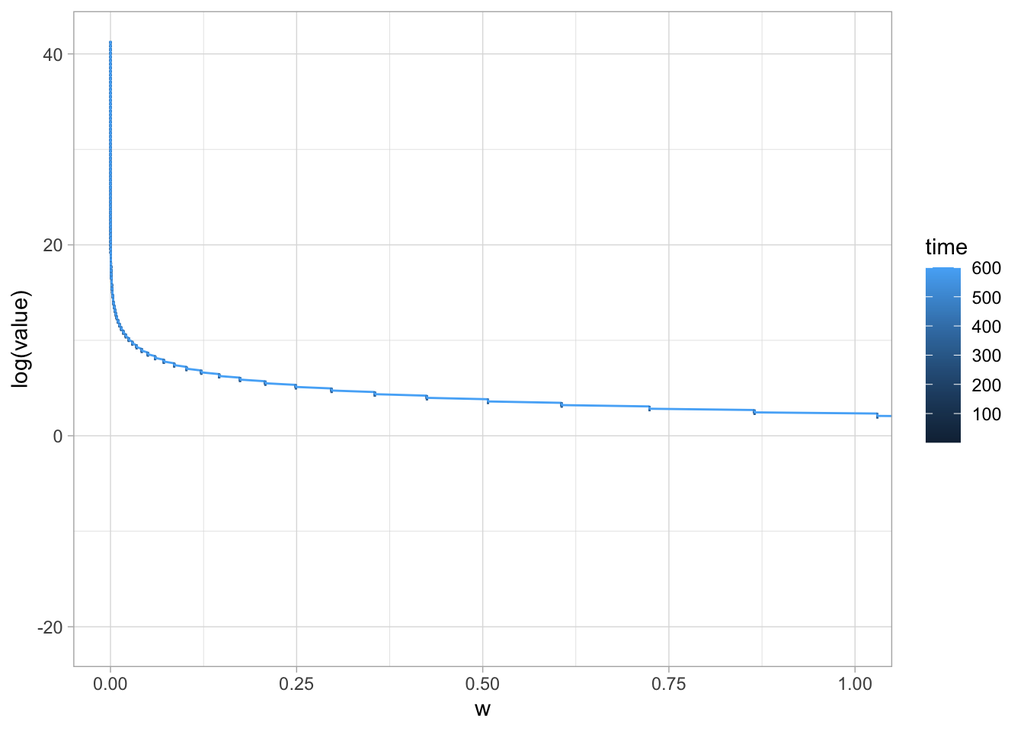

```r
t <- reshape2::melt(plankton_forcing_array)

t %>%
  ggplot(aes(w, log(value), color = time)) +
  coord_cartesian(xlim = c(0, 1)) +
  geom_line()
```

```r
# Seems OK
t %>%
  group_by(time) %>%
  summarise(min = min(w),
            max = max(w)) %>%
  distinct(min)
```

```
# A tibble: 1 × 1
           min
         <dbl>
1 0.0000000113
```

Now I can project the mizer model with time-varying plankton. First I keep the effort and the temperature at their averages during the calibration to isolate the effects.

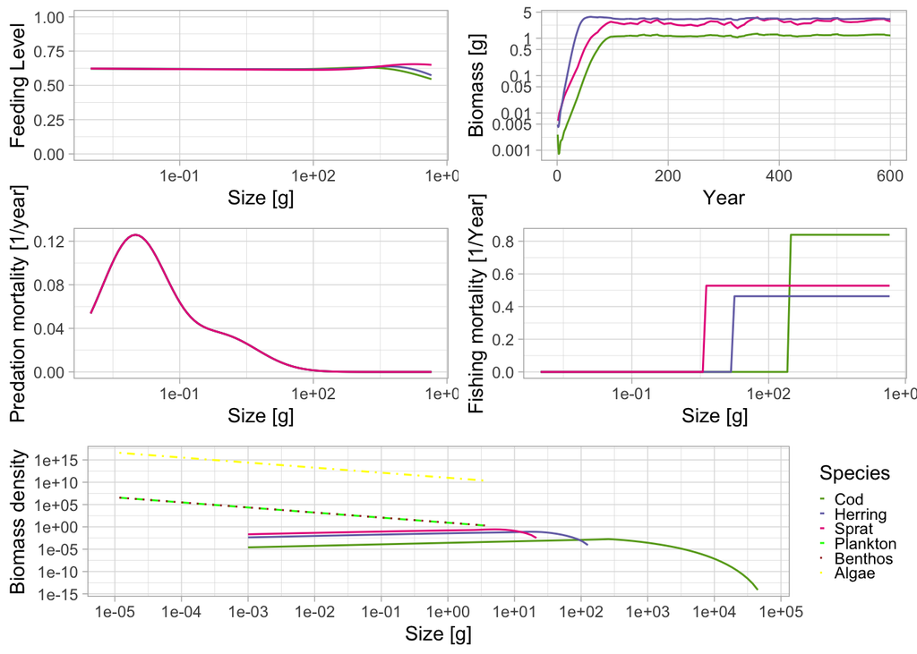

```r
test_fishmip <- project(params,
                        dt = 0.2,
                        effort = projectEffort_cali,
                        temperature = rep(temperature_cali, 600),
                        t_max = 600,
                        plankton_forcing = TRUE,
                        plankton_forcing_array = plankton_forcing_array_dt
                        )

plot(test_fishmip)
```

Works nicely. Now vary everything!

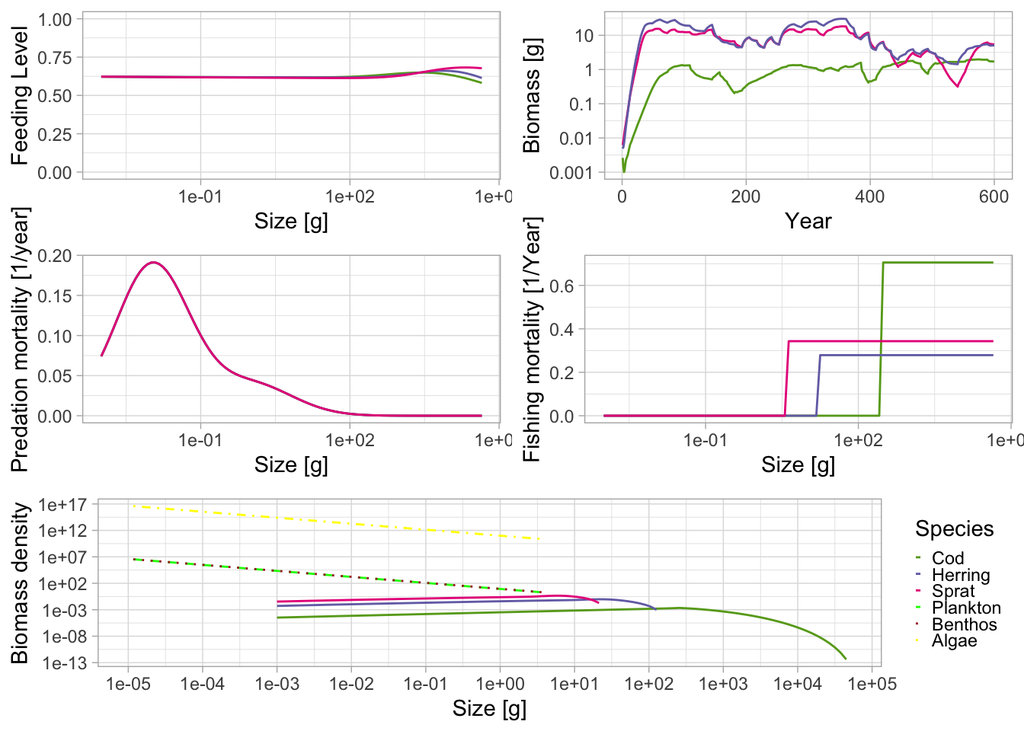

```r
true_fishmip <- project(params,
                        dt = 0.2,
                        effort = projectEffort,
                        temperature = projectTemp$temp_agg, #temp_agg is the year_averaged temperature
                        t_max = 600,
                        plankton_forcing = TRUE,
                        plankton_forcing_array = plankton_forcing_array_dt
                        )

plot(true_fishmip)
```

We can compare the SSBs from the GCB paper model (run with calibration averages) with the full-FishMIP models. But note, we don’t expect them to be very similar because the FishMIP scenarios still use a model that is calibrated to different fishing efforts and temperatures (and resources)

```r
# Can we now compare the Fishmip fish biomass with gcb biomass?
pred_test_fishmip <- colMeans(getSSB(true_fishmip)[c(I(dim(true_fishmip@n)[1]-24):dim(true_fishmip@n)[1]), ] ) * 2.49e+11 / (1e9)
pred_gcb <- colMeans(getSSB(gcb)[c(I(dim(gcb@n)[1]-20):dim(gcb@n)[1]), ] ) * 2.49e+11 / (1e9)

pred_test_fishmip <- getSSB(test_fishmip) %>%
  as_tibble() %>%
  rownames_to_column() %>%
  rename(time = rowname) %>%
  mutate(time = as.numeric(time)) %>%
  ungroup() %>%
  #filter(time > 300) %>%
  mutate(model = "fishmip")
```

```
rename: renamed one variable (time)
```

```
mutate: converted 'time' from character to double (0 new NA)
```

```
ungroup: no grouping variables
```

```
mutate: new variable 'model' (character) with one unique value and 0% NA
```

```r
pred_gcb <- getSSB(gcb) %>%
  as_tibble() %>%
  rownames_to_column() %>%
  rename(time = rowname) %>%
  mutate(time = as.numeric(time)) %>%
  ungroup() %>%
  #filter(time > 300) %>%
  mutate(model = "gcb")
```

```
rename: renamed one variable (time)
```

```
mutate: converted 'time' from character to double (0 new NA)
```

```
ungroup: no grouping variables
```

```
mutate: new variable 'model' (character) with one unique value and 0% NA
```

```r
comp <- bind_rows(pred_test_fishmip, pred_gcb) %>%
  pivot_longer(c("Cod", "Sprat", "Herring"))
```

```
pivot_longer: reorganized (Cod, Sprat, Herring) into (name, value) [was 1200x5, now 3600x4]
```

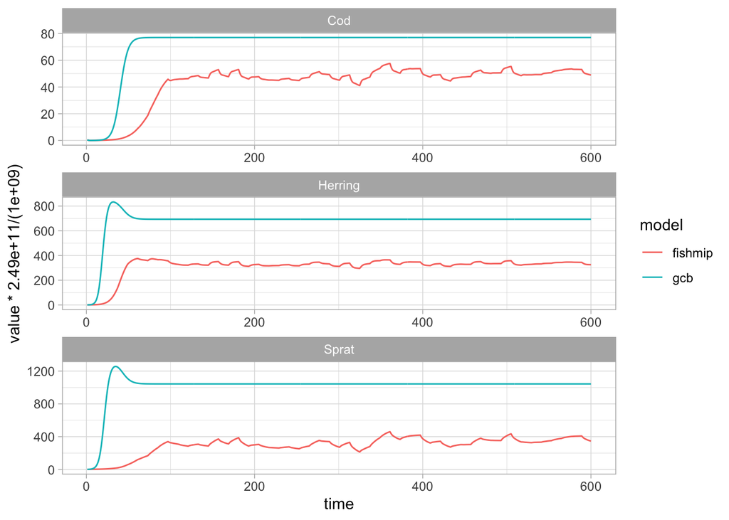

```r
ggplot(comp, aes(time, value * 2.49e+11 / (1e9), color = model)) +
  geom_line() +
  facet_wrap(~name, scales = "free", ncol = 1)
```

Lastly, check the final two years SSBs and compare with the observed

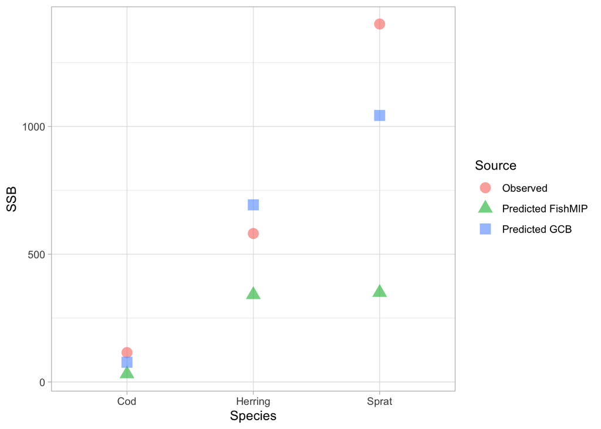

```r
# For the FishMIP, I chose the one with forcing but kept to steady state from projection with temperature and effort held at FishMIP averages in 1992-2004
pred_FishMIP <- colMeans(getSSB(test)[c(I(dim(test@n)[1]-24):dim(test@n)[1]), ] ) * 2.49e+11 / (1e9)
pred_gcb <- colMeans(getSSB(gcb)[c(I(dim(gcb@n)[1]-24):dim(gcb@n)[1]), ] ) * 2.49e+11 / (1e9)

ssb_eval <- data.frame(SSB = c(obs, pred_FishMIP, pred_gcb),
                       Source = rep(c("Observed", "Predicted FishMIP", "Predicted GCB"), each = 3),
                       Species = rep(balticParams$species, 3))

ggplot(ssb_eval, aes(Species, SSB, shape = Source, color = Source)) +
  geom_point(size = 4, alpha = 0.6)
```